# Participation motifs and the emergence of organization in open productions - ScienceDirect

- [View **PDF**](https://www.sciencedirect.com/science/article/pii/S0954349X13000039/pdfft?md5=cb8cdc4bfc320c7f38bbfc5073161a0e&pid=1-s2.0-S0954349X13000039-main.pdf)

## [Structural Change and Economic Dynamics](https://www.sciencedirect.com/journal/structural-change-and-economic-dynamics)

[Volume 29](https://www.sciencedirect.com/journal/structural-change-and-economic-dynamics/vol/29/suppl/C), June 2014, Pages 40-57

# Participation *motifs* and the emergence of organization in open productions☆

[Alessandro Lomi <sup>a</sup>](https://www.sciencedirect.com/author/6603743386/alessandro-lomi), , ,

https://doi.org/10.1016/j.strueco.2013.01.002[Get rights and content](https://s100.copyright.com/AppDispatchServlet?publisherName=ELS&contentID=S0954349X13000039&orderBeanReset=true)

Full text access

## Abstract

We study how organization emerges from interdependent problem solving behavior of participants in an open production system. We consider individual problem solving attempts as acts of production embedded in an evolving bipartite network which affiliates organizational participants to organizational problems. We document how local configurations of network ties (or *motifs*) linking participants to problems emerge from – but at the same time sustain decentralized problem solving activities. Structural characteristics of the observed network suggest specific dependence hypotheses linking participants to problems. We explore these hypotheses by examining problem solving attempts performed by 135 participants in an open source software project on the 719 problems (software bugs) recorded during a complete release cycle of the software. Our empirical strategy relies on the specification and estimation of newly derived stochastic actor-oriented models (SAOM) originally conceived for the analysis of social networks. We find that individual problem solving behavior is activated by the interaction between local configurations of network ties, the level of experience of problem solvers, and the level of difficulty of problems. The discussion focuses on the broad theoretical implications of the study for the relation between work practices and organizational structures.

### Highlights

► Organization of open productions emerges from individual problem solving attempts. ► Individual action is embedded in bipartite networks linking individuals to problems. ► Collaborative problem solving is enabled and sustained by network-based processes. ► Decentralized problem solving induces self-organizing configurations of network ties. ► Empirical evidence from a study of an open source software project is presented.

## JEL classification

D23

L17

L23

## Keywords

Free/open source software

Organization of production

Bipartite networks

Stochastic actor-oriented models

Emergence of organization

## 1. Introduction and overview

One way to think about organizations is as problem solving arrangements designed to economize on the limited cognitive resources of their members, simplify decisions, encourage coordination, and reproduce production relations (Cyert and March, 1963, March and Simon, 1958). How do organizations accomplish this set of complex objectives? Available answers reveal fundamental differences in assumptions about the nature of economic organization (Arrow, 1974, Cohen et al., 1972, Coleman, 1973, Marglin, 1974, Nelson and Winter, 1982, Williamson, 1991). Despite these differences, one would be hard pressed to find answers that do not appeal to some concept of hierarchy – the “complex system in which each of the subsystems is subordinated by an authority relation to the system it belongs to” (Simon, 1962: p. 470).

Hierarchies make organizational decisions possible by specifying authority relations, allocating decision rights, and by focusing individual attention on specific problems (March and Simon, 1958). Hierarchies facilitate decisions also by restricting access to potential solutions and decision opportunities (Cohen et al., 1972). According to Radner (1993), for example, it is efficient to have decisions in organizations based on only partial information, and in fact to have “different decisions based on different information” (Radner, 1993: p. 1110). In the context of production relations, however, different decisions based on different information, and taken by different people are likely to involve some form of explicit coordination (Malone and Crowston, 1994).

The view that authority relations embedded in hierarchical structures also provide coordination is well grounded in theories of bounded rationality (Simon, 1951, Simon, 1969). However, the emergence of open, collaborative forms of economic organization (Bailey et al., 2012, Lerner and Tirole, 2002, Powell et al., 1996, von Krogh et al., 2012) invites reconsideration of the relation between organizational structure and actual production practices. “Communities,” “movements,” “networks,” and “ecologies” are terms more frequently adopted to describe how open forms of economic production actually work (Healy and Schussman, 2003, von Krogh et al., 2003). The more conventional terms used to describe bounded production activities such as “firms,” “companies,” or “bureaucracies” somehow fail to convey the sense of collective action underlying successful open production projects (von Hippel and von Krogh, 2003).

The empirical opportunity to advance our organizational understanding of open productions is offered by a specific Free/Open source software (F/OSS) project – a specific open form of economic production (Bonaccorsi et al., 2006, Lerner and Tirole, 2002). According to von Krogh and von Hippel F/OSS projects may be defined as (2003: p. 1149): “Internet-based networks or communities of software developers. The software they develop is made freely available to all that adhere to the licensing terms specified by the open source project.” Free/Open source software is produced under licenses that facilitate public ownership. In this sense F/OSS projects may be viewed as forms of private production of complex public goods (Bessen, 2006).

From an organizational angle the distinctive feature of F/OSS projects is the relative openness of their boundaries to the contribution of participants who can join voluntarily and leave almost at any time.<sup>1</sup> In turn, the fluidity in patterns of organizational participation, and the associated variability in the level of attention that contributors devote to organizational problems greatly diminish the value of formal incentive systems and control mechanisms based on authority relations.

In F/OSS projects both the individual “decision to participate” and the “decision to produce” are more difficult to explain in terms of contingent (short-term) incentives that the organization may be able to provide (March and Simon, 1958). What might then explain individual engagement in – and commitment to – the resolution of organizational problems? What might account for sustained collaboration among participants in F/OSS production projects? And, finally, what factors might ensure alignment between individual objectives and the commitment to the resolution of collective problems?

Economists interested in these questions have frequently emphasized motivational issues because, as Lerner et al. (2006: p. 114) put it: “The decision to contribute without pay to freely available software may seem mysterious to economists.” With important qualifications (O’Mahony, 2003, O’Mahony and Ferraro, 2007, Ferraro and O’Mahony, 2012), students of organizations have framed the problem of participation in open production projects in a similar way (Roberts et al., 2006, Shah, 2006). Specialists of open innovation have provided detailed accounts of how motivational issues in F/OSS projects may be alleviated by the presence of appropriable private benefits inherent in aspects of participation to the provision of a collective good (von Hippel and von Krogh, 2003, von Krogh et al., 2012).

Motivational issues are obviously relevant to the understanding of how F/OSS projects (and indeed any kind of organization) actually work. In this paper, however, we attempt an alternative approach grounded in a detailed examination of how individual problem solving attempts actually happen as a consequence of dynamic work practices linking problems and participants (Barley and Kunda, 2001, Jarzabkowski et al., 2012). More specifically, we examine how organizational problems and organizational participants encounter each other in a space of potential decision opportunities and how such encounters give rise to *dynamic* network *motifs*, or local “patterns of interconnections occurring in complex networks at numbers that are significantly higher than those in randomized networks” (Milo et al., 2002: p. 824). In the specific case we examine, network *motifs* define *dynamic* configurations of network ties with meaningful organizational properties that sustain decentralized problem solving activities in the absence of exogenous hierarchical ordering – i.e., in the absence of organizational structures that precede individual acts of production. Our analytical focus is on the micro-structure underlying the dynamics of network *motifs*.

Building, conceptually, on the work of Marengo and Dosi (2005) we consider organizational problem solving as a particular *form* of production activity. We posit that the bipartite network linking participants to problems internalizes the information generated by individual acts of production. Participant-producers use this information to allocate their attention and decide their level of commitment to the overall project. The global structure of this open production system emerges from individual acts of problem solving which crystallize into distinct local configurations of network ties in which participants and problems are embedded. To reveal these configurations, we specify and estimate a dynamic stochastic actor-oriented model recently developed for bipartite networks (Conaldi et al., 2012, Koskinen and Edling, 2012). The specific behavior being modeled is the individual decision of organizational participants to change their level of engagement in organizational problem solving activities as revealed by their association to problems. The individual decision to confront organizational problems is modeled as a function of: (i) exogenous characteristics of the problems; (ii) exogenous characteristics of the participants, and (iii) endogenous characteristics of the network linking participants to problems. We use computer simulation to show that the empirical estimates capture observed structural characteristics of the production system.

The empirical part of the study relies on data that we have collected on problem solving activities observed within *Epiphany* (rebranded as *Web* at the time of this writing) – a well-established F/OSS project started in 2002 with the goal of building a web browser for the GNOME graphical desktop environment. We focus on “bug fixing” – the process of resolving software problems – as one of the primary problem solving activities in the development of F/OSS software (Crowston and Scozzi, 2008). More specifically, we reconstruct and analyze the evolution of the bipartite network emerging from the association between participants and problems within the project. Our dataset includes complete information on problem solving activities related to bug-fixing actions performed by 135 contributors on 719 software problems (software “bugs”) reported during a complete release cycle of the software. While bug fixing is obviously only one of the many problem solving activities carried out within F/OSS projects, it is representative of the decentralized, user-centered process of quality control and improvement that is typically observed in F/OSS productions (Conaldi and Lomi, in press). From this perspective bug fixing represents an essential element in the overall quality control process ensuring quality improvement between successive releases (Michlmayr, 2007).

After this general introduction we organize the paper as follows. The next section sets the analytical stage of the paper by offering a simple but general representation of the bipartite network structure of organizational problem solving attempts in F/OSS projects. Originally developed for the analysis of social groups (Breiger, 1974), bipartite network representations are becoming more common in economics (Easley and Kleinberg, 2010). *Change* in the structure of this network is the main focus of our modeling effort. We compare the observed network structure of organizational problem solving activities with an idealized structure having the same aggregate properties, but generated according to assumptions of dyadic independence – an assumption that is typically maintained in empirical studies. The comparison between the measured network and a sample of comparable simulated networks under condition of dyadic independence reveals the organizational properties that a model of organizational problem solving must reproduce in order to be credible. The third section links some of these properties to *change* in local configurations of network ties – or *dynamic network motifs* (Milo et al., 2002) – that may be responsible for the observed network structure. We identify three possible micro-relational mechanisms that may be responsible for the systematic differences between actual and simulated networks. The fourth section provides a compact discussion on the specification, estimation and evaluation of the empirical model. The results are reported in Section 5. A discussion section concludes the paper.

## 2. The bipartite network structure of organizational problem solving

According to Cohen et al. (1972: p. 1) organizations may be viewed as “collections of choices looking for problems, issues and feelings looking for decision situations in which they might be aired, solutions looking for issues to which they might be an answer, and decision makers looking for work. If we concede that that in organizations “solutions” are carried by “participants,” then organization structures may be reconstructed as a dynamic network of encounters between “people” and “problems.” In this paper we consider “bug fixing” – or attempts to resolve software problems (software “bugs”) by software developers – as a core organizational problem solving activity. Organizational participants are software developers.

Bug fixing has long been recognized as playing an essential role in the development and maintenance of F/OSS products (Crowston, 2008, Michlmayr, 2007). Decentralized bug-fixing activities are frequently viewed as providing a significant contribution to the success of F/OSS projects (Crowston and Scozzi, 2008). Yet, the conditions of extreme decentralization characterizing problem solving activities in F/OSS environments poses the question of how collaboration may be obtained – and possibly sustained – in “the apparently anarchistic process of open source production, in which no one tells anybody else what to do” (Lerner and Tirole, 2001: p. 821).

In decentralized productions characterized by distributed work carried out by highly autonomous participants, the answer to this question does not reside in the design of optimal hierarchical control systems or incentives. Our attempt to address this concern starts from a simple representation of organizational problem solving activities as embedded in networks of connections linking problems and participants – the carriers of potential solutions (Cohen et al., 1972).

In this spirit, consider an organization as a dual association between organizational problems and organizational participants. Define *P* = {*p*<sub>1</sub>, *p*<sub>2</sub>,…, *p*<sub>*n*</sub>} as the set of problems observed at any one time, and *S* = {*s*<sub>1</sub>, *s*<sub>2</sub>,…, *s*<sub>*m*</sub>} as the set of participants present at any one time. The association between problems and participants may then be defined in terms of a rectangular array *Y* = (*P*,*S*,*R*), where the relation *R* ⊆ (*P* × *S*) is defined only between the elements of the two sets, but not among elements within each set (i.e., *P*∩*S* = *∅*). Suppose that *R* is represented by a set of directed edges with origin node in *S* and terminal node in *P* such that the tie variable *y*<sub>*sp*</sub> = 1 if *sRp*, and *y*<sub>*sp*</sub> = 0 otherwise, where *p* and *s* are generic elements of *P* and *S*, respectively. Then, these simple rules of network construction produce a bipartite affiliation network recording the presence of a relation between organizational problems and participants (Easley and Kleinberg, 2010). In the case we examine in this paper, participants are contributors to the project, and problems are software bugs. We concentrate on the binary architecture of the project.

According to this representation, organizational problems and organizational participants are linked by a dual relationship (Breiger, 1974): problems are connected (indirectly) through the set of participants jointly working on their resolution. Dually, organizational participants are connected (indirectly) through the problems they jointly engage. What does the network of problem solving actions linking participants to organizational problems look like? What are its main structural-organizational features? Fig. 1 displays the actual data that we analyze in the empirical part of the paper. Blue squares are project participants and red circles are software bugs. Fig. 1 suggests a core-periphery pattern with few core participants engaged in the resolution of a large number of problems, and a larger periphery of participants characterized by a much lower level of engagement in organizational problem solving activities (Crowston et al., 2006).<sup>2</sup>

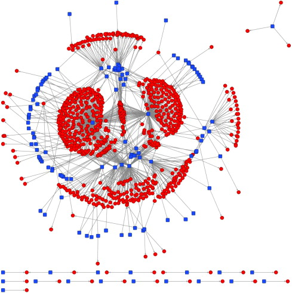

1. [Download: Download full-size image](https://ars.els-cdn.com/content/image/1-s2.0-S0954349X13000039-gr1.jpg)

Fig. 1. The observed organizational problem solving network. Blue squares are participants. Red circles are problems. (For interpretation of the references to color in this figure legend, the reader is referred to the web version of the article.)

The first column in Table 1 reports selected descriptors of the global network generated by interdependent problem solving activities within the project. The overall network is relatively sparse (density = 0.0108), with significant differences in levels of individual engagement as jointly signaled by the number of null dyads, and by the large numbers of 2-stars and 3-stars (number of contributors attempting to resolve multiple problems). The number of four-cycles (two participants working on the same two problems) provides a measure of bipartite clustering – or “closure” (Robins and Alexander, 2004). As we discuss in the next section, bipartite clustering is particularly important because it signals the tendency of participants to repeat collaboration on multiple problems over time.

Table 1. Descriptive statistics for observed network and simulated Bernoulli random graphs (dyad-independence model).

| Statistic: | Observed network | Simulated Bernoulli networks (*N* = 1000) |
| --- | --- | --- |
| Participants | 135 | 135 |
| Problems | 719 | 719 |
| Total number of dyads | 97,065 | 97,065 |
| Network density | 0.011 | 0.011 |
| Edges (outdegree) | 1053 | 1053 |
| 2-stars | 67,248 | 4279.411 |
| 3-stars | 5,231,135 | 9701.999 |
| Mean outdegree distribution | 6.048 | 6.428 |
| St. Dev outdegree distribution | 16.554 | 7.932 |
| Skewness outdegree distribution | 3.577 | 0.908 |
| Mean indegree distribution | 34.240 | 34.240 |
| St. Dev indegree distribution | 109.464 | 108.059 |
| Skewness indegree distribution | 3.386 | 3.134 |
| Bipartite closure (number of four-cycles) | 1492 | 8.129 |

The organizational properties of the observed network become clearly evident when we compare it with a hypothetical random network having the same aggregate structural features (number of nodes and outdegree). Fig. 2 contains a visual representation of a (Bernoulli) bipartite random network simulated on the basis of the statistics computed for the actual network but assuming independence among the participant-problem dyads. We emphasize the dyad-independence assumption underlying the Bernoulli model because (i) this model represents a useful null model for analyzing a more complex hierarchy of dependence structures in bipartite networks (Wang et al., in press), and because (ii) dyad-independence assumptions are commonly – if implicitly – held both in empirical studies based on dyadic data, as well as in theoretical models of organizational decision making. Substantively, if our network of participants-by-problems could be satisfactorily described in terms of a Bernoulli random network, we would conclude that participants have a given latent propensity to participate in organizational problem solving regardless of whatever other participants might do.<sup>3</sup>

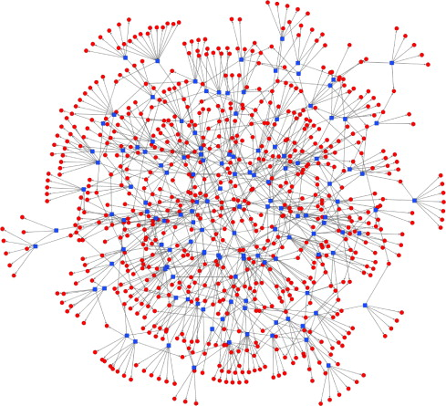

1. [Download: Download full-size image](https://ars.els-cdn.com/content/image/1-s2.0-S0954349X13000039-gr2.jpg)

Fig. 2. Organizational problem solving networks simulated assuming dyadic independence (Bernoulli random graph).

One general conclusion that our simple exercise supports is that a Bernoulli random network is not a good model for our data on organizational problem solving. This conclusion is summarized in Fig. 3 which shows the distribution of organizational problem solving activities (in the form of the outdegree distribution of the observed and simulated networks).

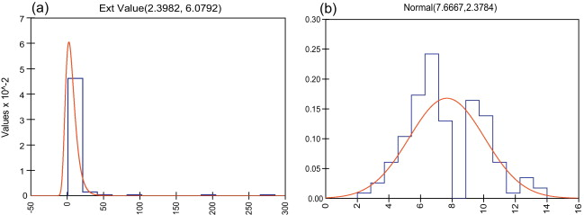

1. [Download: Download full-size image](https://ars.els-cdn.com/content/image/1-s2.0-S0954349X13000039-gr3.jpg)

As Fig. 3 clearly shows, organizational problem solving activities produce aggregate patterns that are not well explained by a baseline model which assumes independence among the contributor-problem dyads. To represent these data accurately we need a more sophisticated understanding of the system of dependencies that support – and simultaneously emerge – from concrete organizational problem solving practices (Barley and Kunda, 2001). We examine this issue next.

## 3. The micro-relational structure of organizational problem solving

Given their decentralized nature, in what sense it might be meaningful to claim that individual problem solving practices represent the elementary building blocks of the production process? In the case that we examine in the empirical part of the paper, this amounts to asking questions about the origins of “organization” itself (Padgett et al., 2003). One way to reason about the origin of organization is to identify elementary components of local structure which capture systematic dependencies between individuals and problems. Because “coordination is defined as managing dependencies” (Malone and Crowston, 1994: p. 91) identifying such dependencies is the first step toward the understanding of how decentralized production activities may be coordinated. In this section we discuss three forms of dependence associated with *change* in local structures linking participants and problems. In the specific case we examine, the *dynamic* network *motifs* we discuss capture specific forms of self-organization that at the same time emerge from – and sustain – individual acts of production.

As we have seen, the actual network of problem solving actions has at least two notable features distinguishing it from the dyad-independent (Bernoulli) model that we have simulated. The first is the skewness in the outdegree distribution. Substantively, this means that engagement of participants is exponentially distributed with few very active participants and a long tail of less active participants. The second is the level of (bipartite) clustering. Substantively this means that participants collaborate in problem solving activities much more frequently than the simple dyad-independence model would predict. These two distinctive structural features of the observed network deserve closer scrutiny as they reveal underlying forms of micro-behavioral mechanisms.

Skewness in the outdegree distribution signals that individual engagement in problem solving activities is characterized by positive feedback, or by the tendency of high (low) levels of current activity to cause an increase (decrease)in future levels of activity. Fig. 4 illustrates the local configuration of network ties associated with self-reinforcement in individual activity.

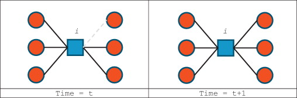

1. [Download: Download full-size image](https://ars.els-cdn.com/content/image/1-s2.0-S0954349X13000039-gr4.jpg)

Fig. 4. Bipartite activity spread.

In Fig. 4 the blue square represents a participant. Red circles represent problems. A link defines the relation “works on,” or “engages.” The dashed light gray edge in the left panel indicates a potential tie that does not yet exist at time *t* but might be established at time *t* + 1. The higher is the level of activity of participant *i* at time *t* (i.e., the higher is the number of problems she engages), the higher will be her level of activity at time *t* + 1. Wang et al. (in press) call the static version of this local configuration of network ties “activity spread.” Over time the effect of this mechanism is to amplify differences in the level of individual engagement which eventually result in a skewed outdegree distribution. This empirical pattern reveals the presence of a limited number of participants contributing a significant level of effort, and a long tail of participants contributing only little – a very well documented feature of participation in F/OSS projects (Crowston, 2008), and in on line communities more generally (Faraj and Johnson, 2011). In the context of the argument that we develop, the importance of this form of local dependence stems from the fact that positive feedback in activity and heterogeneity in individual “motivation” produce the same “structural” consequence: a skewed distribution of problem solving activity.

In the case we examine, it is substantively interesting to establish whether very active participants (participants with high outdegree) are attracted by popular problems (problems with high indegree), i.e., if the global network linking participants to problem is characterized by tendencies toward (bipartite) assortative mixing.<sup>4</sup>

Fig. 5 illustrates bipartite assortativity. At time *t* participant *i* is very active (because he allocates his attention to many problems) and problem *p* is very popular (because it attracts the attention of many participants). At time *t* + 1 participant *i* decides to engage problem *p* thus determining a situation whereby attention is preferentially allocated to more popular problems – a form of preferential attachment (Barabási and Albert, 1999). Bipartite disassortativity (a tendency against direct connection between participants with high outdegree and problems with high indegree) would be evidence that participants prefer to allocate their attention to problems that are not already attended by many other participants. The possible outcome of disassortative mixing would be a more balanced allocation of attention over available problems. In the context of our argument, disassortativity is important because in hierarchical organizations this outcome is frequently obtained by formal mechanisms of attention allocation based, for example, on hierarchical problem scheduling routines.

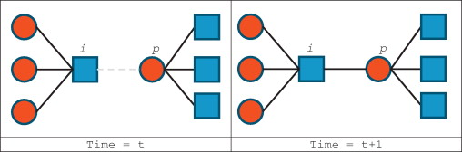

1. [Download: Download full-size image](https://ars.els-cdn.com/content/image/1-s2.0-S0954349X13000039-gr5.jpg)

Fig. 5. Bipartite assortativity.

Perhaps the most striking organizational feature absent from the dyad-independence model is collaboration – the tendency of organizational members to undertake joint problem solving activities. In the network linking organizational participants to organizational problems the tendency toward collaboration is captured by the recurrence of patterns of bipartite closure or “clustering” (Wang et al., in press). Clustering is typically considered as a reliable indicator of cohesion and as one of the most distinctive features of social networks (Newman and Park, 2003, Newman et al., 2001).

As we have discussed in the prior section, in a bipartite affiliation network direct ties between objects of the same kind are not allowed. Ties are only possible between objects belonging to different sets (Easley and Kleinberg, 2010). As a consequence, in bipartite affiliation networks cycles of odd lengths cannot occur: the shortest possible cycle in an affiliation network is a four-cycle. Clustering in a bipartite affiliation network may be defined only in terms of a relation linking pairs of different kinds of objects – in our case participant-problem dyads.

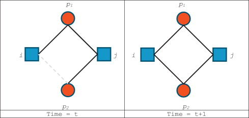

1. [Download: Download full-size image](https://ars.els-cdn.com/content/image/1-s2.0-S0954349X13000039-gr6.jpg)

Fig. 6. Bipartite closure (clustering).

Recent research on Exponential Random Graph Models (ERGM) (Wang et al., in press) emphasizes the conceptual continuity between the four-cycle configuration defined for bipartite affiliation networks, and the “social circuit” configuration originally defined for social networks – networks in which all the nodes are individuals (Pattison and Robins, 2002, Snijders et al., 2006). In a social circuit, the presence of a relation between *i* and *j*, and between *j* and *k*, makes it more likely that *i* and *k* will be connected. This tendency toward closure gives rise to a *circuit of social relations* whose members are more likely to share common information, and gain external recognition as members of a social group with distinctive boundaries. Similarly to the notion of neighborhood in social networks, the four-cycle configuration in bipartite affiliation networks is important for our current purposes because it defines a “setting” for collaboration between organizational members who are linked indirectly through the problems they jointly engage (Pattison and Robins, 2002). The presence of four-cycles in a problem-by-people network reveals self-organizing tendencies toward sustained collaboration.

Our discussion of dynamic bipartite network *motifs* is summarized in Table 2 in which we continue to adopt the graphical conventions introduced earlier. For each dynamic network *motif* that we have discussed, Table 2 reports the (i) associated mechanism of network change; (ii) the configuration of network ties, and (iii) the associated network statistics.

Table 2. Summary of network *motifs*.

Network *motif*

Mechanism

Configuration (*t*<sub>*i*</sub>)

Configuration (*t*<sub>*i* + 1</sub>)

Network statistics

Bipartite activity spread

*Positive feedback in activity* – or tendency for active contributors to engage a progressively larger number of software bugs

$∑pyip∑pyip$

Bipartite assortativity

*Preferential attachment – or* tendency for active contributors to engage popular software bugs

$∑pyip∑pyip∑iyip$

Bipartite closure (clustering)

*Four-cycle –* or tendency for pairs of contributors to engage the same software bugs

$∑i,jyip1yip2yjp1yjp2$

*Note.* Blue squares represent software contributors, red circles represent software bugs. Solid lines represent existing ties. Dashed lines in light gray represent potential ties. *y*<sub>*ip*</sub> indicates a tie between contributor *i* and software bug *p*.

In Table 2 *i and j* denote participants, *p*<sub>1</sub> *and p*<sub>2</sub> denote problems and *y* represents the overall bipartite network. Additional details on the definition of the various effects may be found in Koskinen and Edling (2012), and in Snijders et al. (in press).

After a short description of the empirical setting, in the next section we show how the network *motifs* that we have discussed may be associated with – or reveal – individual preferences, and how such preferences may be incorporated in a statistical model which can be estimated given appropriate data.

## 4. Research design

### 4.1. Data

We collected data on the complete set of problem solving actions recorded during one release cycle of *Epiphany* (rebranded as *Web* at the time of this writing) a successful F/OSS project started in 2002 with the goal of building a web browser for the GNOME graphical desktop environment. We collected information on every problem solving attempt directed at the resolution of software bugs observed from March to September 2006. The data collection involved parsing the web pages of all relevant bug reports in *Epiphany*'s official bug repository – used by contributors to track all problems affecting the software during development – with the specialized software *Bicho* (Robles et al., 2009).

During the release cycle, we recorded a total of 135 contributors taking part in the resolution of 719 software bugs. We constructed the participant-by-problem matrix by coding every action undertaken by contributor *i* on software bug *p* as a tie linking *i* to *p*. We subdivided the observation period into four time panels (*t*<sub>1–4</sub>), each covering a period of approximately 45 days, and recorded all the changes in the network ties linking individual contributors and software bugs. Since we are interested in investigating the process of association between contributors and software bugs, not the intensity of contributors engagement in specific activities, we decided to construct the panels so that a tie represents one or more actions of various types performed on one bug report during one time period. For example, if contributor *i* engages software bug *p* with one or more actions only during the first month of the cycle, the tie linking *i* to *p* will be present in the network at *t*<sub>1</sub> but will be absent from the network in the following panels.

Changing the status or the severity levels of a software bug, modifying its description, marking it as a duplicate, submitting a patch for review, reviewing a patch, or removing an obsolete patch are all examples of actions signaling active engagement in bug-fixing activities. Subscribing oneself or others to receive updates via email about all the actions taken on a specific software bug – i.e., putting oneself or others “in CC” of a bug report – is also counted as a signal of attention because it manifests the willingness to track more closely bug-fixing developments. As a general rule software developers want to avoid email notifications of changes to bug reports unless they have serious interest in a bug. In any case, we consider the action of putting someone else in CC of a bug report as a sign of interest and attention manifested by the contributor who added the third party in CC (clearly not by the third party directly).<sup>5</sup> Finally, the posting of a comment to a bug report is not retained as an action in our dataset because contributors often post comments to report their experiences, or to pose questions and ask clarifications, or simply to solicit a solution.

### 4.2. Variables and measures

Our empirical model specification is based on an attempt to characterize problem solving activities in terms of (i) baseline network change rates; (ii) local network structures; (iii) exogenous individual covariates, and (iv) interactions between network *motifs* and individual covariates.

Change rates control how quickly new opportunities arise for changing network ties linking individuals to problems. *Baseline change rates* refer to the average number of opportunities that individuals face to change their affiliation to problems, either by engaging a new problem or by abandoning prior problems. As we discuss below, we include the effect of *Core developer on rate* to control for the additional choice opportunities that core developers enjoy as contributors “who contribute most of the code and oversee the design and evolution of the project”(Crowston and Howison, 2005: p. 7).

Local *network structures* are associated with self-organizing properties which represent the main focus of the study. The specific *motifs* we incorporate in the model capture systematic dependencies created by the dual association between participants and problems. We include two endogenous network effects in addition to those represented by the three *motifs* that we have discussed (positive feedback, preferential attachment, and closure). The first is *Outdegree* (*density*) which we include to capture the baseline tendency of contributors to allocate their attention to software bugs, i.e., the likelihood that contributor *i* will engage software bug *p* at all. We expect the estimate of the associated parameter to be negative to reflect the fact that problem solving activities are costly. A less substantive reason underlying this expectation has to do with the relatively low density of the network. Of course this more empirical interpretation of the negative outdegree parameter is not inconsistent with our more substantive argument based on the costs of taking action: networks are sparse precisely because ties may be costly to establish and maintain. The second is *Software bug popularity spread* which captures the tendency of software bugs that are already engaged by many contributors to be progressively more (or less) likely to attract additional contributors. These additional forms of local dependence are summarized in Table 3.

Table 3. Summary of endogenous network controls.

Parameter

Included to control for

Configuration (*t*<sub>*i*</sub>)

Configuration (*t*<sub>*i* + 1</sub>)

Network statistics

Outdegree (density)

Overall tendency to engage a software bug

$∑pyip$

Software bugpopularity spread

Tendency for popular software bugs to attract extra contributors

$∑pyip∑iyip$

*Note.* Blue squares represent software contributors, red circles represent software bugs. Solid lines represent existing ties. Dashed lines represent potential ties. *y*<sub>*ip*</sub> indicates a tie between contributor *i* and software bug *p*.

Exogenous covariates may refer to characteristics of both individuals (e.g., tenure), as well as problems (e.g., difficulty). Exogenous individual covariates are included to control for the tendency of differences among problems and among participants to affect individual problem solving attempts. Among exogenous actor-specific covariates referring to software contributors, *Core developer* is included to control for the well-known tendency of core developers to perform higher levels of activity within open source projects.

We identified as core developers seven contributors who signed under the header “The Epiphany developers” a message sent to the mailing list of the project. The message outlines their planned developments for *Epiphany* in the years to come.<sup>6</sup> The set of seven core developers includes the maintainer of Epiphany's code base at the time. The definition is therefore exogenous to the bug-fixing process that we render in our bipartite matrices. It captures a special status acquired because of code production outside bug fixing that is reflected in special privileges in the manipulation of the code repository, which remains distinct from the bug repository. *Contributor tenure* is included to control for the effect of experience in the project. The variable records whether or not a contributor was active in any of *Epiphany*'s release cycles previous to the one we analyze. In this respect the covariate is also fully exogenous as it captures activity in bug fixing before the beginning of 6-month release cycle that we analyze. Three out of the four core developers active in bug fixing during the release cycle resulted being experienced contributors also. *Contributor CC’ing only* is included to tease out the effect of being active in the project only by being in CC of bug reports.

Table 4. Summary table for actor-specific covariates (contributors = 135, software bugs = 719).

| Attribute | Type | Motivation | Operationalization | Proportion |
| --- | --- | --- | --- | --- |
| Contributor tenure | Constant | Controls for the effect of learning | One if a contributor was active in the prior release cycle, zero otherwise | 0.430 |
| Core developer | Constant | Controls for the effect of formal roles | One if a contributor is classified as “core developer,” zero otherwise | 0.029 |
| Contributor CC’ing only | Changing | Controls for the effect of marginal roles | One if a contributor was involved only in cc’ing activities, zero otherwise | 0.155(*t*<sub>1</sub>) 0.141(*t*<sub>2</sub>) 0.133(*t*<sub>3</sub>) |
| Software bugseverity | Constant | Controls for the effect of centralizing tendencies | One if a software bug had a severity level above “normal” in the prior release cycle, zero otherwise | 0.349 |
| Software bugcommunication | Changing | Controls for the effect of awareness in the project | One if a software bug lies in the upper quartile of the distribution of number of received comments | 0.168(*t*<sub>1</sub>) 0.227(*t*<sub>2</sub>) 0.191(*t*<sub>3</sub>) |
| Software bug CC’ing | Changing | Controls for the effect of centralizing tendencies | One if a software bug lies in the upper quartile of the distribution of number of contributors assigned to software bugs in carbon copy | 0.136(*t*<sub>1</sub>) 0.153(*t*<sub>2</sub>) 0.129(*t*<sub>3</sub>) |

Covariates may enter the model specification in a variety of ways. Perhaps the simplest is as a “sender effect” – to capture the tendency of a specific attribute to cause an increase (or, as the case may be, a decrease) in the outdegrees.<sup>7</sup> Finally, actor-specific covariates may be interacted with structural network effects to capture the tendency of nodes having specific attributes to become part of specific local network structures. Snijders et al. (2010b) offer a detailed discussion of the various possibilities in the more general context of stochastic actor-based models for social networks. In the analysis of bipartite networks the situation is slightly more complicated by the fact that there are two sets of elements and, therefore, two distinct sets of nodal properties to take into account.

We include in the model four interaction terms in an attempt to document how the effect of embeddedness in local (sub-network) structures may vary according to the individual characteristics of participants and problems. *Software bug severity four-cycle* and *Contributor-Software bug severity assortativity* are included to control for the specific tendency of severe bugs – respectively – to attract additional (or fewer) active contributors, and to be part of local collaboration clusters. The same logic applies to *Contributor tenure four-cycle* and *Contributor tenure-Software bug assortativity*. A summary of interaction terms included in our model is shown in Table 5.

Table 5. Summary of actor-relations interaction terms.

Parameter

Included to control for

Configuration (*t*<sub>*i*</sub>)

Configuration (*t*<sub>*i* + 1</sub>)

Network statistics

Contributor-Bug severity assortativity

Tendency for active contributors to engage severe popular software bugs

$∑pyipvp∑pyip∑iyip$

Contributor tenure-Software bug assortativity

Tendency for active experienced contributors to engage popular software bugs

$∑pyipvi∑pyip∑iyip$

Bug severity four-cycle

Tendency for pairs of contributors to engage the same severe software bugs

$∑i,pyip1vp1yip2yjp1yjp2$

Contributor tenure four-cycle

Tendency for pairs of experienced contributors to engage the same software bugs

$∑i,pyip1viyip2yjp1yjp2$

*Note.* Black squares (circles) represent contributors (software bugs) with an attribute, dotted squares (circles) represent contributors (software bugs) without that same attribute. Solid lines represent existing ties. Dashed lines represent potential ties. *y*<sub>*ip*</sub> indicates a tie between contributor *i* and software bug *p*. *v*<sub>*i*</sub> indicates that contributor *i* is an experienced contributor whereas *v*<sub>*p*</sub> indicates that software bug *p* is a severe bug. Therefore *y*<sub>*ip*1</sub>*v*<sub>*i*</sub> indicates a tie between experienced contributor *i* and software bug *p*<sub>1.</sub>

### 4.3. Stochastic actor-oriented models

The empirical part of the paper is based on the specification and estimation of stochastic actor-oriented models (SAOM) (Snijders, 1996, Snijders, 2001). SAOM were initially derived for the analysis of network panel data based on the assumption that the observed realizations of a network are produced by a continuous-time Markov process on the space of all directed graphs on a given node set (Snijders et al., 2010a).

During the last decade, the SAOM approach has been considerably expanded and refined by Snijders and his collaborators (Snijders, 2005, Snijders et al., 2010b, Steglich et al., 2010). Empirical applications of SAOM models for social (or “unipartite”) networks are becoming relatively more common in studies of peer effects and other forms of social influence (Lewis et al., 2012, Lomi et al., 2011). In this paper we present one of the first empirical applications of SAOM for bipartite networks which have become available only recently (Koskinen and Edling, 2012, Snijders et al., in press). SOAM assume that the network structure observed at any one time develops as a result of interdependent individual decisions unfolding in continuous time. Actors (network nodes) are only allowed to change the ties under their direct control (i.e., values in their own row), and no single actor has control over the entire network structure. In SAOM the evolution of the network is decomposed into its smallest possible components defined in terms of change in single ties. Statistically, these assumptions lead to a representation of the network structure that is observed at any moment as a realization of a continuous-time Markov Chain *Y*(*t*) – where observed realizations are *y*(*t*<sub>*τ*</sub>) (with *τ* = 1,2,…,*T*) (Snijders, 2001). At any point in time the process produces the observed network *Y*(*t*) = *y*. In the specific case we discuss *y* is a bipartite network of size *NxM*, with tie variables *y*<sub>*ip*</sub> = 1 if participant *i* engages problem *p*, and *y*<sub>*ip*</sub> = 0 otherwise. Formally, the model describes a continuous-time Markov process, whose state space is defined in terms of all the possible combinations of network ties (Snijders, 2001).

Linking SAOM to data requires specification of two main components. The first is a *rate function λ*<sub>*i*</sub>(*α*,*y*) which controls how quickly opportunities for changing network ties arise. In our case, the relevant decision concerns the change in the individual portfolio of network ties to problems. Participants get opportunities to change their affiliation to problems at the rate:(1)$λY(t)=expα0+∑kαkxik.$

The rate may be constant between observation moments (when *α*<sub>*k*</sub> = 0, for all *k*), or it may change depending on actor-specific covariates (*x*<sub>*ik*</sub>).

In the model we estimate below, we make the number of opportunities for change dependent on differences in the status of participants (defined in terms of “core” versus “non-core” status). In this way we allow for the possibility that core developers enjoy greater freedom to change their affiliations to problems over time.

The second component of SAOM is the individual decision of participants (rows) to change their affiliation to problems (columns). This decision is controlled by an *evaluation function* (*f*<sub>*i*</sub>) representing the relative attractiveness for participant *i* of moving from *y* to *y*′, where *y* and *y*′ are successive network configurations differing in terms of only one tie.<sup>8</sup> Among the possible *m* changes that a participant can make at any one time, she is assumed to choose so that *f*<sub>*i*</sub>(*y*, *y*′, *x*) + *e*(*y*, *y*′, *x*) is maximized. In this formulation *f*<sub>*i*</sub> is a deterministic evaluation function, *x* is a set of covariates, and *e* is a random disturbance, or “error term.” The deterministic part of the evaluation function assumes the typical linear form (Snijders et al., 2010b).(2)$fiβ,y=∑kβksik(y),$where *f*<sub>*i*</sub>(*β*,*y*) is the value of the evaluation function for participant *i* depending on the state of the network (*y*), and the terms *s*<sub>*ik*</sub>(*y*) are the “effects” which may be associated with: (i) network *motifs*; (ii) actor-specific covariates representing “exogenous” characteristics of the participants or the problems, and (iii) interactions between network *motifs* and exogenous covariates. Finally *β*<sub>*k*</sub> are parameters representing the weight, or strength of the corresponding effect.

Individual decisions to change network ties are based on a comparison of the values of the evaluation function computed across the permissible choice options. More specifically, if *y*′ = *y*(*i* → *p*) denotes the network that would be observed if participant *i* changed his connections to problem *p* (creation of a new tie or termination of an existing tie, dependent on the existence of a tie), then the probability to observe one change would be:(3)$Pr(y(i→p)x)=exp∑kβksik(y(i→p),x∑hexp∑kβksiky(i→h),x.$

Under appropriate distributional assumption<sup>9</sup> the model just described is consistent with revealed preferences interpretations as established by McFadden (1974) and described, for example, in Maddala (1983: Chapter 3). If participant *i* changes his affiliation profile (his row in the bipartite network) producing a change from configuration *y* to *y*′, then he is acting as if he *prefers y*′ *to y*. Because of our analytical focus on individual decision to change single ties the analysis is restricted to the binary architecture of the networks. The weight of the edges is ignored. Squartini et al. (2011) provide extensive discussion of the advantages and possible liabilities of focusing on binary (unweighted) networks in the context of models for international trade data.

### 4.4. Model estimation and evaluation

Because model estimation involves computing the transition probabilities between all possible neighboring states of the network, the state space of the model consists of all possible trajectories linking network configurations observed in adjacent time periods. Under such conditions conventional statistical estimation is unfeasible but parameters estimates may be obtained via an iterative Robbins and Monro (1951) stochastic approximation algorithm using the Method of Moments (MoM) estimation procedure (Snijders, 2001). The algorithm computes multiple times the evolution process of the network via Markov Chain Monte Carlo (MCMC) simulations implied by the current model specification (Snijders, 2002). Parameters values are updated after each simulation reflecting the deviations between generated and observed statistics corresponding to the effects included in the model (Schweinberger and Snijders, 2007). For every estimated parameter averages and standard errors of these deviations are computed across all the simulated networks and used to compute *convergence t-ratios*. Convergence *t*-ratios for all the estimates we report in Table 6 are smaller (in absolute value) than 0.1 – the critical value established for the model to be considered fully convergent (Snijders, 2001). As suggested by Ripley et al. (2012), we repeated such estimation 3000 times to obtain reliable estimates of the standard errors. Goodness-of-fit for SAOM is generally based on a comparison between networks obtained by model-based simulation, and observed network data. The general statistical argument underlying this approach is developed by Hunter et al. (2008) in the context of Exponential Random Graph Models. In the empirical part of the study we follow this analytical strategy to compare the degree distributions of the observed affiliation networks to those generated in the simulations (3000 in our case) that make use of the final estimated parameters in order to estimate their standard errors. The observed network should fall within one standard deviation from the mean calculated across the simulated networks for all degree values for the model fit to be considered satisfactory. The rationale for focusing on the degree distribution to assess model fit stems from the fact that degree distributions are one of the main structural features of (social and other) networks. Degree distributions, however, are not directly parameterized in the models that we specify. Therefore a good fit would imply that simulated networks – generated given our specification of the model – reproduce global characteristics of the observed networks only by using the estimated parameters for local network structures and exogenous actor-specific covariates included in the model specification. As a global measure of fit, we report the results of Wald-type tests performed on the various models. R-SIENA (Ripley et al., 2012) was the software used to obtain the estimates and the GOF tests which we report in the next section.<sup>10</sup>

Table 6. Method of moment estimates of AOM for bipartite networks.

| Empty Cell | Effects | Model 1 | Model 2 | Model 3 |
| --- | --- | --- | --- | --- |
| Change rate effects | Rate of network change 1 | 2.560 (0.171) | 3.457 (0.367) | 3.786 (0.465) |
|  | Rate of network change 2 | 1.889 (0.129) | 1.872 (0.131) | 2.002 (0.148) |
|  | Rate of network change 3 | 4.172 (0.218) | 3.940 (0.304) | 3.966 (0.449) |
|  | Core developer effect on rate | 3.216*** (0.077) | 3.385*** (0.086) | 3.300*** (0.112) |
| Exogenous actor-specific covariates | Software bug communication | −0.749*** (0.117) | −0.849*** (0.122) | −0.835*** (0.119) |
|  | Software bug severity | −0.250*** (0.063) | −0.304*** (0.065) | −0.361** (0.112) |
|  | Software bug CC’ing | 0.381** (0.117) | 0.629*** (0.126) | 0.627*** (0.140) |
|  | Core developer | 1.562*** (0.105) | −0.652*** (0.174) | −0.967*** (0.240) |
|  | Contributor CC’ing only | −0.613*** (0.120) | −0.256* (0.112) | −0.245 (0.139) |
|  | Contributor tenure | 0.960*** (0.089) | −0.165 (0.123) | 0.411** (0.161) |
| Endogenous network effects | Outdegree | −2.499*** (0.069) | −3.578*** (0.306) | −3.642*** (0.357) |
|  | Four-cycles |  | 0.033* (0.016) | −0.008 (0.056) |
|  | Software bug popularity |  | −0.061 (0.192) | −0.271 (0.226) |
|  | Contributor activity |  | 0.452*** (0.050) | 0.496*** (0.043) |
|  | Contributor-Software bug assortativity |  | −0.005* (0.002) | 0.014 (0.011) |
| Network effects – actor-specific interaction | Software bug severity four-cycles |  |  | 0.072** (0.028) |
|  | Contributor-Software bug severity assortativity |  |  | 0.002** (0.001) |
|  | Contributor tenure four-cycles |  |  | 0.075 (0.065) |
|  | Contributor tenure-Software assortativity |  |  | −0.038* (0.016) |
| Wald *χ*<sup>2</sup> statistic (df) |  | 3273(8)*** | 131 (4)*** | 33(4)*** |

****

*p* < 0.05.

****

*p* < 0.01.

****

*p* < 0.001.

## 5. Analyses

### 5.1. Results

Our discussion of the empirical results is organized around Table 6. Convergence *t*-ratios for all reported estimates are smaller than 0.1 in absolute value. Our null model (Model 1), accounts only for the overall propensity of contributors to work on software bugs, and for the effects of exogenous actor-specific covariates on such propensity. The effects of network *motifs* on the individual choice of contributors are added in our main-effects model (Model 2). Finally our full model (Model 3) adds to Model 2 interaction terms that account for the effects of network *motifs* on the choices of specific categories of contributors with regard to specific type of software bugs.

The *rates of network change* (1–3) provide an estimate of the average number of opportunities for changing individual affiliation to problems. In the full model contributors face approximately four opportunities for change in the last time period (*t*<sub>3 → 4</sub>). Across all models choice opportunities appear to decrease in the middle of the release cycle. As expected, core developers enjoy significantly more choice opportunities than all other contributors throughout the release cycle, as captured by the strongly positive and significant *Core developer* effect which implies an average of three extra opportunities. The negative *Outdegree* parameter indicates that attempting to resolve a software problem is a costly action: conditional on the other effects in the model the value of −3.642 for the outdegree parameter implies that the odds for any tie linking a developer to a problem to be present versus absent are exp(−3.642) = 0.026. The negative outdegree effect suggests that attention is a scarce resource. Problems of attention allocation arise as a consequence. This interpretation is consistent with much of what we know about empirical applications of SAOM (Steglich et al., 2006).

In Model 1 we include exogenous contributor-specific as well as problem-specific covariates. The negative and significant parameter estimate for *software bug communication* indicates that software bugs generating more discussion also tend to “scare away” contributors. Specifically, the odds for a software bug generating exceptional discussion to be chosen by a contributor against not being chosen are [exp(−0.749)=] 0.473 times as large as the odds for a software bug stimulating a lower level of interest. This result carries interesting implications as it points out that an excessive amount of discussion on a problem is not necessarily fostering problem solving actions. Previous research corroborates this view by showing that the effect of communication on bug resolution is two-folded: communication addressing technical dependencies reduces resolution time, whereas communication that does not may be even detrimental to project viability (Wagstrom et al., 2010).

In Model 2 we include local dependencies taking the form of the various network *motifs* that we have discussed. The positive and significant parameter estimate for *Contributor activity* shows evidence of reinforcing feedback: the higher the level of current activity, the higher the level of future activity. One possible interpretation of this effect is as a consequence of processes of “learning by doing” which progressively lowers the cost of individual problem solving attempts. The non-significant parameter for *Software bug popularity* indicates that already popular software bugs are not more likely to attract additional attention in the future. As a consequence of the associated tendency toward decentralized problem solving, over time attention is more homogenously distributed across problems. The significant parameter estimate for *four-cycle* indicates that contributors tend to develop patterns of repeated collaboration: collaborating on a problem makes it more likely that two contributors will collaborate again on future problems. The negative and significant *Contributor-Software bug assortativity* parameter indicates that contributors choose to work on problems that are not already engaged by other participants: this represents strong evidence against preferential attachment. Finally, parameters estimates for exogenous contributor-specific covariates in Model 2 reveal that experienced contributors do not exhibit a significantly different choice behavior once we control for the main reinforcing feedback effect. Similarly, the parameter estimate associated with core developers becomes negative after we control for the main effects of reinforcing feedback and experience. Core developers show a negative propensity to work on software bugs that are not embedded in more complex local configurations. This may be due to the fact that whereas core developers are – by definition – central in the production of software code, not necessarily always play a more active role than other experienced contributors in bug fixing. Together with the very small number of core developers involved in the project this accounts for the negative sign of the parameter in Model 2.

The inclusion of interaction terms in Model 3 does not alter the parameter estimates for exogenous covariates already included in the previous model, with the exception of *Contributor CC’ing only* and *Contributor tenure*. In Model 3 experienced contributors do show higher propensity to attempt resolution of software bugs, thus suggesting that a positive effect of experiential learning might influence the association between problems and participants (Argote and Epple, 1990) over and above the effect of network *motifs* taken into account. This happens when the main effect of experience is considered together with the significant and negative *Contributor tenure-Software bug assortativity* effect. This interaction effect, together with the main effect of *Contributor-Software bug assortativity* becoming non-significant, indicates that only experienced contributors *prefer* to allocate their attention to problems that are not already attended to by other participants. The consequence is a tendency towards an anti-hierarchical pattern in which the most popular problems are “decoupled” from the most active – and experienced – participants. At the same time, the positive and significant *Contributor-Software bug severe assortativity* effect reveals the presence of a tendency for already popular severe bugs to be chosen by even more contributors in the future. Together with the *Four-Cycle* effect, the significant and positive *Bug Severity four-cycle* indicates that contributors are more likely to develop patterns of sustained collaboration when attempting to resolve severe software problems.

### 5.2. Model evaluation

Beyond individual parameters, it is also important to assess the overall goodness-of-fit of convergent models, i.e., to assess how well the model reproduces the observed network structure. In Fig. 7, the box-plots show how the networks simulated during model estimation cover the (in and out) degree distributions observed in our data. Results of Model 3 are shown only for the last panel (*t*<sub>4</sub>).<sup>11</sup> For each set of actors, red lines represent observed degree distributions, and box-plots represent frequency distributions for different degree values in 3000 simulated networks. As a heuristic rule, satisfactory fit is achieved when, for all degree values, the observed frequency falls within one standard deviation from the mean frequency of the simulated networks.

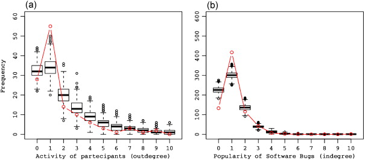

Fig. 7. Diagnostic goodness-of-fit (GOF) plots for (a) activity of participants (bipartite outdegree distribution) and (b) popularity of problems, or attractiveness (bipartite indegree distribution). The solid red lines represent the data. The boxplots summarize the distribution of 3000 bipartite networks simulated on the basis of the empirical estimates (i.e., under the assumption that the model specifies the correct observation-generating mechanism). The GOF plots refer only to the last transition observed, i.e., to the transition between time periods *t*<sub>3</sub> and *t*<sub>4</sub>. (For interpretation of the references to color in this figure legend, the reader is referred to the web version of the article.)

Results show that the model does not fully capture the outdegree distributions, even if Model 3 improves over the fit of the other models (goodness-of-fit diagnostic plots not shown). In particular the model has problems tracking peaks in the activity of participants (Fig. 7a) and in the popularity of problems (Fig. 7b). As a global measure or fit, we include in Table 4 the chi-square statistics corresponding to the Wald-type test that are carried out to assess how close the model is to the observations. This test works by restricting all newly included parameters to zero and then by testing the restricted against the unrestricted model. Both chi-square statistics associated with Model 2 and Model 3 show a significant improvement over the previous model (*α* = 0.05).

## 6. Discussion and conclusions

According to Barley and Kunda (2001: p. 76): “All theories of organizing are at least implicitly linked to some image of the concrete activities that they purport to describe and explain. In most instances these activities are what people call work. Work and organization are bound in dynamic tension because organizational structures are, by definition, descriptions of and templates for ongoing patterns of action.” In this paper we have attempted to articulate one way in which this theoretical tension can be resolved by considering “work” activities and organizational “structures” not just as dual concepts each definable only in terms of the other (Breiger, 2000), but as aspects of action – or “work” itself. In our models, the problem solving actions of developers are “concrete activities” and simultaneously “organization structure” in the sense of Barley and Kunda (2001).

Our starting point was the general view that organizational problem solving may be interpreted as a concrete production/transformation process (Marengo and Dosi, 2005). The context selected for study usefully illustrates some of the main empirical implications of this claim. In F/OSS productions, individual problem solving actions produce both modifications in material aspects of the product, as well as real-time information on change in the level of collective participation to organizational production activities. Differently from more conventional settings, in open productions these changes are immediately visible throughout the community of participants-producers and are not mediated by organizational hierarchies. As a consequence individual problem solving behavior is affected directly by information about the level of collective effort. We have suggested specific dependence mechanisms that make this embedded production system work in practice. We have shown how individual attempts crystallize into local configurations of network ties with meaningful self-organizing properties. Finally, we have shown how these properties relate to structural dimensions of the global network of problem solving attempts. A distinct contribution of our work is that the models we have specified and estimated are oriented toward individual behavior but, at the same time, they also capture salient aggregate features of the production system that was actually observed.

Our modeling efforts are consistent with T.C. Schelling view that: “people's behavior depends on *how many* are behaving a particular way, or how much they are behaving that way” (1978: p. 94. Emphasis in the original). Like many of Shelling's examples (1978; Chapter 3), in our case individual decisions generate endogenously freely accessible information that potential participants may use to determine *their own* level of contribution to collective production efforts. What we have added to this general view is a series of specific mechanisms through which individual acts of production concatenate and reproduce behavioral patterns that may be interpreted as outcomes of motivational forces.

Four main limitations of our work deserve special attention as they reveal clear opportunities for further research. The first limitation is inherent in our focus on differences in individual decisions to contribute to organizational problem solving activities – a focus motivated by the extreme skewness in the empirical distribution of effort. Our emphasis on individual decisions and effort precluded analysis of outcomes of such decision. As a consequence we were unable to assess, for example, how effectively problems were actually resolved during the release cycle of the software, how long on average problems remained unresolved within the project (the problem latency time), and how durable (or stable) were the solutions that contributors implemented (Cohen et al., 1972). Addressing these issues requires a research design oriented toward the *consequences* of problem solving behavior. In this paper we focused on its *antecedents* i.e., on the individual decisions that affiliate organizational participants to organizational problems. Data necessary to examine the effectiveness of observed problem solving attempts are available and may support future efforts to study how the effectiveness of problem solving attempts depends on the embeddedness of individual behavior in a network of production relations that enables and constrains organizational problem solving.

The second limitation derives from our attempt to frame our work as a search for an explanation to participation in open productions alternative to explanations based individual motivation. In the absence of direct measures of individual motivation we are unable to provide a full assessment of the empirical merits of our argument. We have seen that our model does not fully cover the outdegree distribution: peaks in individual participation are not well explained within our model. It is possible, therefore, that future research may benefit from a more balanced approach that admits that motivation may play a role in individual decisions to contribute to collective production projects. This path for future research is both promising, as well as fraught with difficulties (Alexy and Leitner, 2011). According to Krishnamurthy, for example, in the context of open source software projects (Krishnamurthy, 2006: p. 31): “While we understand that there is task specialization, we do not know the motivations of individuals to accept less glamorous roles. If the metaphor of a gift economy is to hold, the open source community should have its share of drones willing to do monotonous and boring tasks to move the product further along. What motivates the drones?” Our paper suggests one way in which this question may be addressed.

Thirdly, one way to frame our study is as a longitudinal case study on a single F/OSS project. In addition, we have examined a relatively large and successful project, and not a random sample of representative F/OSS productions. As a consequence issues arise about the empirical scope of the results we have reported – an issue that may be addressed only through systematic replication.

A final limitation relates to our exclusive focus on bug-fixing activities in the development of F/OSS products. Important as error-discovery and error-correction activities may be (Michlmayr, 2007), they represent only one specific aspect of F/OSS productions. The actual contribution of lines of software code would probably be a more natural example of how organizational problem solving and organizational production processes may be linked. We have no particular reason to believe that the actual production of software code will be affected by the same structural logics that we have documented in our analysis of bug-fixing activities. We acknowledge that we have examined only one specific sub-process of F/OSS development. Understanding how production is embedded in networks that relate participants to multiple tasks, and how such networks are themselves transformed by – and co-evolve with production remain issues that future research will need to address.

Despite these various limitations of our work we believe that explaining individual participation in open productions remains an important general issue because it may help to improve our understanding of voluntary contribution to the provision of public goods. As such, our study documents how open productions may provide rich empirical material for experimenting with feasible organizational solutions to this general problem.

## References

1. Alexy and Leitner, 2011

   O. Alexy, M. Leitner

   A fistful of dollars: are financial rewards a suitable management practice for distributed models of innovation?

   European Management Review, 8 (2011), pp. 165-185

   [Crossref](https://doi.org/10.1111/j.1740-4762.2011.01017.x)[View in Scopus](https://www.scopus.com/inward/record.url?eid=2-s2.0-80054067097&partnerID=10&rel=R3.0.0)Google Scholar
2. Argote and Epple, 1990

   L. Argote, D. Epple

   Learning curves in manufacturing

   Science, 247 (1990), pp. 920-924

   [Crossref](https://doi.org/10.1126/science.247.4945.920)[View in Scopus](https://www.scopus.com/inward/record.url?eid=2-s2.0-0025021555&partnerID=10&rel=R3.0.0)[Google Scholar](https://scholar.google.com/scholar_lookup?title=Learning%20curves%20in%20manufacturing&publication_year=1990&author=L.%20Argote&author=D.%20Epple)
3. Arrow, 1974

   K.J. Arrow

   The Limits of Organization

   Norton, New York, NY (1974)

   [Google Scholar](https://scholar.google.com/scholar_lookup?title=The%20Limits%20of%20Organization&publication_year=1974&author=K.J.%20Arrow)
4. Barabási and Albert, 1999

   A.L. Barabási, R. Albert

   Emergence of scaling in random networks

   Science, 286 (1999), pp. 509-512

   [View in Scopus](https://www.scopus.com/inward/record.url?eid=2-s2.0-0038483826&partnerID=10&rel=R3.0.0)[Google Scholar](https://scholar.google.com/scholar_lookup?title=Emergence%20of%20scaling%20in%20random%20networks&publication_year=1999&author=A.L.%20Barab%C3%A1si&author=R.%20Albert)
5. Barley and Kunda, 2001

   S. Barley, G. Kunda

   Brining work back in

   Organization Science, 12 (1) (2001), pp. 76-95

   [View in Scopus](https://www.scopus.com/inward/record.url?eid=2-s2.0-0141674125&partnerID=10&rel=R3.0.0)[Google Scholar](https://scholar.google.com/scholar_lookup?title=Brining%20work%20back%20in&publication_year=2001&author=S.%20Barley&author=G.%20Kunda)
6. Bailey et al., 2012

   D. Bailey, P. Leonardi, S. Barley

   The lure of the virtual

   Organization Science, 23 (5) (2012), pp. 485-1504

   [Crossref](https://doi.org/10.1111/j.1549-0831.2012.00087_2.x)[Google Scholar](https://scholar.google.com/scholar_lookup?title=The%20lure%20of%20the%20virtual&publication_year=2012&author=D.%20Bailey&author=P.%20Leonardi&author=S.%20Barley)
7. Bessen, 2006

   J. Bessen

   Open source software: free provision of complex public goods

   B. Jürgen, J. Philipp, H. Schröder (Eds.), The Economics of Open Source Software Development, Elsevier B. V., Amsterdam (2006)

   [Google Scholar](https://scholar.google.com/scholar_lookup?title=Open%20source%20software%3A%20free%20provision%20of%20complex%20public%20goods&publication_year=2006&author=J.%20Bessen)
8. Bonaccorsi et al., 2006

   A. Bonaccorsi, S. Giannangeli, C. Rossi

   Entry strategies under competing standards: hybrid business models in the open source software industry

   Management Science, 52 (7) (2006), pp. 1085-1098

   [Crossref](https://doi.org/10.1287/mnsc.1060.0547)[View in Scopus](https://www.scopus.com/inward/record.url?eid=2-s2.0-33745598162&partnerID=10&rel=R3.0.0)Google Scholar
9. Breiger, 1974

   R.L. Breiger

   The duality of persons and groups

   Social Forces, 53 (2) (1974), pp. 181-190

   [View in Scopus](https://www.scopus.com/inward/record.url?eid=2-s2.0-84959830077&partnerID=10&rel=R3.0.0)[Google Scholar](https://scholar.google.com/scholar_lookup?title=The%20duality%20of%20persons%20and%20groups&publication_year=1974&author=R.L.%20Breiger)
10. Breiger, 2000

    R. Breiger

    A toolkit for practice theory

    Poetics, 27 (2–3) (2000), pp. 91-115

    [View PDF](https://www.sciencedirect.com/science/article/pii/S0304422X99000261/pdf?md5=1a524b39000d98e3aaab585c5cf22b66&pid=1-s2.0-S0304422X99000261-main.pdf)[View article](https://www.sciencedirect.com/science/article/pii/S0304422X99000261)[View in Scopus](https://www.scopus.com/inward/record.url?eid=2-s2.0-0010597309&partnerID=10&rel=R3.0.0)[Google Scholar](https://scholar.google.com/scholar_lookup?title=A%20toolkit%20for%20practice%20theory&publication_year=2000&author=R.%20Breiger)
11. Cohen et al., 1972

    M.D. Cohen, J.G. March, J.P. Olsen

    A garbage can model of organizational choice

    Administrative Science Quarterly, 17 (1) (1972), pp. 1-25

    [Crossref](https://doi.org/10.2307/2392088)[View in Scopus](https://www.scopus.com/inward/record.url?eid=2-s2.0-84912299544&partnerID=10&rel=R3.0.0)[Google Scholar](https://scholar.google.com/scholar_lookup?title=A%20garbage%20can%20model%20of%20organizational%20choice&publication_year=1972&author=M.D.%20Cohen&author=J.G.%20March&author=J.P.%20Olsen)
12. Coleman, 1973

    J.S. Coleman

    Power and the Structure of Society

    Norton, New York, NY (1973)

    [Google Scholar](https://scholar.google.com/scholar_lookup?title=Power%20and%20the%20Structure%20of%20Society&publication_year=1973&author=J.S.%20Coleman)
13. Conaldi and Lomi, in press

    Conaldi, G., Lomi, A. The dual network structure of organizational problem solving: a case study on open source software development. Social Networks, in press.

    Google Scholar
14. Conaldi et al., 2012

    G. Conaldi, A. Lomi, M. Tonellato

    Dynamic models of affiliation and the network structure of problem solving in an Open Source Software project

    Organizational Research Methods, 15 (3) (2012), pp. 385-412

    [Crossref](https://doi.org/10.1177/1094428111430541)[View in Scopus](https://www.scopus.com/inward/record.url?eid=2-s2.0-84862164960&partnerID=10&rel=R3.0.0)Google Scholar
15. Crowston and Howison, 2005

    K. Crowston, J. Howison

    The social structure of free and open source software development

    First Monday, 10 (2) (2005)

    [Google Scholar](https://scholar.google.com/scholar_lookup?title=The%20social%20structure%20of%20free%20and%20open%20source%20software%20development&publication_year=2005&author=K.%20Crowston&author=J.%20Howison)
16. Crowston, 2008

    K. Crowston

    The bug fixing process in proprietary and Free/Libre Open Source Software: a coordination theory analysis

    V. Grover, M.L. Markus (Eds.), Business Process Transformation: Advances in Management Information Systems, M.E. Sharpe, Armonk, NY (2008)

    Google Scholar
17. Crowston and Scozzi, 2008

    K. Crowston, B. Scozzi

    Bug-fixing practices within free/libre open source software development teams

    Journal of Database Management, 19 (2) (2008), pp. 1-30

    [Crossref](https://doi.org/10.4018/jdm.2008040101)[View in Scopus](https://www.scopus.com/inward/record.url?eid=2-s2.0-50549103724&partnerID=10&rel=R3.0.0)[Google Scholar](https://scholar.google.com/scholar_lookup?title=Bug-fixing%20practices%20within%20freelibre%20open%20source%20software%20development%20teams&publication_year=2008&author=K.%20Crowston&author=B.%20Scozzi)
18. Crowston et al., 2006

    Crowston, K., Wei, K., Li, Q., Howison, J., 2006. Core and periphery in Free/Libre and Open Source software team communications. Institute for Software Research. Paper 489. http://repository.cmu.edu/isr/489.

    Google Scholar
19. Cyert and March, 1963

    R.M. Cyert, J.G. March

    A Behavioral Theory of the Firm

    Prentice-Hall, Englewood Cliffs, NJ (1963)

    [Google Scholar](https://scholar.google.com/scholar_lookup?title=A%20Behavioral%20Theory%20of%20the%20Firm&publication_year=1963&author=R.M.%20Cyert&author=J.G.%20March)
20. Easley and Kleinberg, 2010

    D. Easley, J. Kleinberg

    Networks, Crowds, and Markets: Reasoning About a Highly Connected World

    Cambridge University Press, New York, NY (2010)

    [Google Scholar](https://scholar.google.com/scholar_lookup?title=Networks%2C%20Crowds%2C%20and%20Markets%3A%20Reasoning%20About%20a%20Highly%20Connected%20World&publication_year=2010&author=D.%20Easley&author=J.%20Kleinberg)
21. Faraj and Johnson, 2011

    S. Faraj, S.L. Johnson

    Network exchange patterns in online communities

    Organization Science, 22 (2011), pp. 1464-1480

    [Crossref](https://doi.org/10.1287/orsc.1100.0600)[View in Scopus](https://www.scopus.com/inward/record.url?eid=2-s2.0-82455191664&partnerID=10&rel=R3.0.0)[Google Scholar](https://scholar.google.com/scholar_lookup?title=Network%20exchange%20patterns%20in%20online%20communities&publication_year=2011&author=S.%20Faraj&author=S.L.%20Johnson)
22. Ferraro and O’Mahony, 2012

    F. Ferraro, S. O’Mahony

    Managing the boundary of an open project

    J. Padgett, W.W. Powell (Eds.), Market Emergence And Transformation, Princeton University Press, Princeton, NJ (2012)

    [Google Scholar](https://scholar.google.com/scholar_lookup?title=Managing%20the%20boundary%20of%20an%20open%20project&publication_year=2012&author=F.%20Ferraro&author=S.%20O%E2%80%99Mahony)
23. Frank, 1981

    O. Frank

    A survey of statistical methods for graph analysis

    S. Leinhardt (Ed.), Sociological Methodology, Jossey-Bass, San Francisco (1981), pp. 110-155

    [Crossref](https://doi.org/10.2307/270740)[Google Scholar](https://scholar.google.com/scholar_lookup?title=A%20survey%20of%20statistical%20methods%20for%20graph%20analysis&publication_year=1981&author=O.%20Frank)
24. Healy and Schussman, 2003

    Healy, K., Schussman, A., 2003. The Ecology of Open Source Software Development. Unpublished working paper.

    [Google Scholar](https://scholar.google.com/scholar?q=Healy%2C%20K.%2C%20Schussman%2C%20A.%2C%202003.%20The%20Ecology%20of%20Open%20Source%20Software%20Development.%20Unpublished%20working%20paper.)
25. Hunter et al., 2008

    D.R. Hunter, S.M. Goodreau, M.S. Handcock

    Goodness of fit of social network models

    Journal of the American Statistical Association, 103 (481) (2008), pp. 248-258

    [Crossref](https://doi.org/10.1198/016214507000000446)[View in Scopus](https://www.scopus.com/inward/record.url?eid=2-s2.0-41249094522&partnerID=10&rel=R3.0.0)[Google Scholar](https://scholar.google.com/scholar_lookup?title=Goodness%20of%20fit%20of%20social%20network%20models&publication_year=2008&author=D.R.%20Hunter&author=S.M.%20Goodreau&author=M.S.%20Handcock)
26. Jarzabkowski et al., 2012

    P. Jarzabkowski, J.K. Le, M. Feldman

    Toward a theory of coordinating: creating coordinating mechanisms in practice

    Organization Science, 23 (4) (2012), pp. 907-927

    [Crossref](https://doi.org/10.1287/orsc.1110.0693)[View in Scopus](https://www.scopus.com/inward/record.url?eid=2-s2.0-84867039762&partnerID=10&rel=R3.0.0)Google Scholar
27. Koskinen and Edling, 2012

    J. Koskinen, C. Edling

    Modelling the evolution of a bipartite network: peer referral in interlocking directorates

    Social Networks, 34 (2012), pp. 309-322

    [View PDF](https://www.sciencedirect.com/science/article/pii/S0378873310000122/pdfft?md5=667d7b38e4af4f1a2e105bc16ec2ce28&pid=1-s2.0-S0378873310000122-main.pdf)[View article](https://www.sciencedirect.com/science/article/pii/S0378873310000122)[View in Scopus](https://www.scopus.com/inward/record.url?eid=2-s2.0-84861339055&partnerID=10&rel=R3.0.0)Google Scholar
28. Krishnamurthy, 2006

    S. Krishnamurthy

    On the intrinsic and extrinsic motivation of free/libre/open source (FLOSS) developers

    Knowledge, Technology, and Policy, 18 (2006), pp. 17-39

    [Crossref](https://doi.org/10.1007/s12130-006-1002-x)[Google Scholar](https://scholar.google.com/scholar_lookup?title=On%20the%20intrinsic%20and%20extrinsic%20motivation%20of%20freelibreopen%20source%20%20developers&publication_year=2006&author=S.%20Krishnamurthy)
29. Lerner et al., 2006

    J. Lerner, P.A. Pathak, J. Tirole

    The dynamics of open-source contributors

    American Economic Review, 96 (2) (2006), pp. 114-118

    [Crossref](https://doi.org/10.1257/000282806777211874)[View in Scopus](https://www.scopus.com/inward/record.url?eid=2-s2.0-33744549818&partnerID=10&rel=R3.0.0)[Google Scholar](https://scholar.google.com/scholar_lookup?title=The%20dynamics%20of%20open-source%20contributors&publication_year=2006&author=J.%20Lerner&author=P.A.%20Pathak&author=J.%20Tirole)
30. Lerner and Tirole, 2001

    J. Lerner, J. Tirole

    The open source movement: key research questions

    European Economic Review, 45 (4–6) (2001), pp. 819-826

    [View PDF](https://www.sciencedirect.com/science/article/pii/S0014292101001246/pdfft?md5=f8e42cc93dda11506ed5f6cbfbc38eae&pid=1-s2.0-S0014292101001246-main.pdf)[View article](https://www.sciencedirect.com/science/article/pii/S0014292101001246)[View in Scopus](https://www.scopus.com/inward/record.url?eid=2-s2.0-0035000251&partnerID=10&rel=R3.0.0)[Google Scholar](https://scholar.google.com/scholar_lookup?title=The%20open%20source%20movement%3A%20key%20research%20questions&publication_year=2001&author=J.%20Lerner&author=J.%20Tirole)
31. Lerner and Tirole, 2002

    J. Lerner, J. Tirole

    Some simple economics of open source

    Journal of Industrial Economics, 50 (2) (2002), pp. 197-234

    [Crossref](https://doi.org/10.1111/1467-6451.00174)[View in Scopus](https://www.scopus.com/inward/record.url?eid=2-s2.0-0036000474&partnerID=10&rel=R3.0.0)[Google Scholar](https://scholar.google.com/scholar_lookup?title=Some%20simple%20economics%20of%20open%20source&publication_year=2002&author=J.%20Lerner&author=J.%20Tirole)
32. Lewis et al., 2012

    K. Lewis, M. Gonzalez, J. Kaufman

    Social selection and peer influence in an online social network

    Proceedings of the National Academy of Science, 109 (1) (2012), pp. 68-72

    [Crossref](https://doi.org/10.1073/pnas.1109739109)[View in Scopus](https://www.scopus.com/inward/record.url?eid=2-s2.0-84856003521&partnerID=10&rel=R3.0.0)Google Scholar
33. Lomi et al., 2011

    A. Lomi, T.A.B. Snijders, V.J. Torló

    Why are some more peer than others? Evidence from a longitudinal study of social networks and individual academic performance

    Social Science Research, 40 (2011), pp. 1506-1520

    [View PDF](https://www.sciencedirect.com/science/article/pii/S0049089X11001141/pdfft?md5=1ded33ce461a2eea17cf697ba48713fb&pid=1-s2.0-S0049089X11001141-main.pdf)[View article](https://www.sciencedirect.com/science/article/pii/S0049089X11001141)[View in Scopus](https://www.scopus.com/inward/record.url?eid=2-s2.0-80053218763&partnerID=10&rel=R3.0.0)Google Scholar
34. Maddala, 1983

    G.S. Maddala

    Limited-Dependent and Qualitative Variables in Econometrics

    Cambridge University Press (1983)

    [Google Scholar](https://scholar.google.com/scholar_lookup?title=Limited-Dependent%20and%20Qualitative%20Variables%20in%20Econometrics&publication_year=1983&author=G.S.%20Maddala)
35. Malone and Crowston, 1994

    T. Malone, K. Crowston

    The interdisciplinary study of coordination

    ACM Computing Surveys, 26 (1) (1994), pp. 87-117

    [View in Scopus](https://www.scopus.com/inward/record.url?eid=2-s2.0-0028401441&partnerID=10&rel=R3.0.0)[Google Scholar](https://scholar.google.com/scholar_lookup?title=The%20interdisciplinary%20study%20of%20coordination&publication_year=1994&author=T.%20Malone&author=K.%20Crowston)
36. March and Simon, 1958

    J.G. March, H.A. Simon

    Organizations

    Wiley, New York (1958)

    [Google Scholar](https://scholar.google.com/scholar_lookup?title=Organizations&publication_year=1958&author=J.G.%20March&author=H.A.%20Simon)
37. Marglin, 1974

    S.A. Marglin

    What do bosses do? The origins and functions of hierarchy in capitalist production

    Review of Radical Political Economics, 6 (2) (1974), pp. 60-112

    [Crossref](https://doi.org/10.1177/048661347400600206)[View in Scopus](https://www.scopus.com/inward/record.url?eid=2-s2.0-84950033657&partnerID=10&rel=R3.0.0)[Google Scholar](https://scholar.google.com/scholar_lookup?title=What%20do%20bosses%20do%20The%20origins%20and%20functions%20of%20hierarchy%20in%20capitalist%20production&publication_year=1974&author=S.A.%20Marglin)
38. Marengo and Dosi, 2005

    L. Marengo, G. Dosi

    Division of labor, organizational coordination and market mechanisms in collective problem-solving

    Journal of Economic Behavior and Organization, 58 (2) (2005), pp. 303-326

    [View PDF](https://www.sciencedirect.com/science/article/pii/S0167268105001538/pdfft?md5=6b6707aa5bbeed436c939c85b7a15da4&pid=1-s2.0-S0167268105001538-main.pdf)[View article](https://www.sciencedirect.com/science/article/pii/S0167268105001538)[View in Scopus](https://www.scopus.com/inward/record.url?eid=2-s2.0-25844447311&partnerID=10&rel=R3.0.0)Google Scholar
39. McFadden, 1974

    McFadden, D., 1974. Conditional logit analysis of qualitative choice behavior. In: Zarembka, P. Editor, Frontiers in Econometrics, Academic Press: New York, NY, 105–142.

    Google Scholar
40. Michlmayr, 2007

    Michlmayr, M., 2007. Quality improvement in volunteer free and open source software projects: exploring the impact of release management. PhD. dissertation. Centre for Technology Management, Institute for Manufacturing, University of Cambridge (U.K).

    Google Scholar
41. Milo et al., 2002

    R. Milo, S. Shen-Orr, S. Itzkovitz, N. Kashtan, D. Chklovskii, U. Alon

    Network motifs: simple building blocks of complex networks

    Science, 298 (5594) (2002), pp. 824-827

    [View in Scopus](https://www.scopus.com/inward/record.url?eid=2-s2.0-0037174670&partnerID=10&rel=R3.0.0)Google Scholar
42. Nelson and Winter, 1982

    R. Nelson, S. Winter

    An Evolutionary Theory of Economic Change

    Harvard University Press, Cambridge, MA (1982)

    [Google Scholar](https://scholar.google.com/scholar_lookup?title=An%20Evolutionary%20Theory%20of%20Economic%20Change&publication_year=1982&author=R.%20Nelson&author=S.%20Winter)
43. Newman, 2003

    M.E.J. Newman

    Mixing patterns in networks

    Physical Review E, 67 (2003), p. 026126

    [Google Scholar](https://scholar.google.com/scholar_lookup?title=Mixing%20patterns%20in%20networks&publication_year=2003&author=M.E.J.%20Newman)
44. Newman and Park, 2003

    M.E.J. Newman, J. Park

    Why social networks are different from other types of networks

    Physical Review E, 68 (2003), p. 036122

    [Google Scholar](https://scholar.google.com/scholar_lookup?title=Why%20social%20networks%20are%20different%20from%20other%20types%20of%20networks&publication_year=2003&author=M.E.J.%20Newman&author=J.%20Park)
45. Newman et al., 2001

    M.E.J. Newman, S.H. Strogatz, D.J. Watts

    Random graphs with arbitrary degree distributions and their applications

    Physical Review E, 64 (2001), p. 026118

    Google Scholar
46. O’Mahony, 2003

    S. O’Mahony

    Guarding the commons: how community managed software projects protect their work

    Research Policy, 32 (7) (2003), pp. 1179-1198

    [View PDF](https://www.sciencedirect.com/science/article/pii/S0048733303000489/pdfft?md5=cad4e70eb6c7ee7773b0b0f40cb4ed14&pid=1-s2.0-S0048733303000489-main.pdf)[View article](https://www.sciencedirect.com/science/article/pii/S0048733303000489)[View in Scopus](https://www.scopus.com/inward/record.url?eid=2-s2.0-0038447919&partnerID=10&rel=R3.0.0)[Google Scholar](https://scholar.google.com/scholar_lookup?title=Guarding%20the%20commons%3A%20how%20community%20managed%20software%20projects%20protect%20their%20work&publication_year=2003&author=S.%20O%E2%80%99Mahony)
47. O’Mahony and Ferraro, 2007

    S. O’Mahony, F. Ferraro

    The emergence of governance in an open source community

    Academy of Management Journal, 50 (5) (2007), pp. 1079-1106

    [View in Scopus](https://www.scopus.com/inward/record.url?eid=2-s2.0-36749092836&partnerID=10&rel=R3.0.0)[Google Scholar](https://scholar.google.com/scholar_lookup?title=The%20emergence%20of%20governance%20in%20an%20open%20source%20community&publication_year=2007&author=S.%20O%E2%80%99Mahony&author=F.%20Ferraro)
48. Padgett et al., 2003

    J.F. Padgett, D. Lee, N. Collier

    Economic production as chemistry

    Industrial and Corporate Change, 12 (4) (2003), pp. 843-877

    [View in Scopus](https://www.scopus.com/inward/record.url?eid=2-s2.0-0042927961&partnerID=10&rel=R3.0.0)[Google Scholar](https://scholar.google.com/scholar_lookup?title=Economic%20production%20as%20chemistry&publication_year=2003&author=J.F.%20Padgett&author=D.%20Lee&author=N.%20Collier)
49. Pattison and Robins, 2002

    P.E. Pattison, G.L. Robins

    Neighborhood-based models for social networks

    Sociological Methodology, 32 (2002), pp. 301-337

    [Crossref](https://doi.org/10.1111/1467-9531.00119)[View in Scopus](https://www.scopus.com/inward/record.url?eid=2-s2.0-0036420701&partnerID=10&rel=R3.0.0)[Google Scholar](https://scholar.google.com/scholar_lookup?title=Neighborhood-based%20models%20for%20social%20networks&publication_year=2002&author=P.E.%20Pattison&author=G.L.%20Robins)
50. Powell et al., 1996

    W. Powell, L. Koput, K. Smith-Doerr

    Interorganizational learning and the locus of innovation: networks of learning in biotechnology

    Administrative Science Quarterly, 41 (1996), pp. 116-145

    [Crossref](https://doi.org/10.2307/2393988)[View in Scopus](https://www.scopus.com/inward/record.url?eid=2-s2.0-0030306449&partnerID=10&rel=R3.0.0)Google Scholar
51. Radner, 1993

    R. Radner

    The organization of decentralized information processing

    Econometrica, 61 (5) (1993), pp. 1109-1146

    [Crossref](https://doi.org/10.2307/2951495)[Google Scholar](https://scholar.google.com/scholar_lookup?title=The%20organization%20of%20decentralized%20information%20processing&publication_year=1993&author=R.%20Radner)
52. Ripley et al., 2012

    R.M. Ripley, T.A.B. Snijders, P. Preciado Lopez

    Manual for R-Siena

    University of Oxford, Department of Statistics, Nuffield College, Oxford, UK (2012)

    [Google Scholar](https://scholar.google.com/scholar_lookup?title=Manual%20for%20R-Siena&publication_year=2012&author=R.M.%20Ripley&author=T.A.B.%20Snijders&author=P.%20Preciado%20Lopez)
53. Roberts et al., 2006

    J.A. Roberts, I.H. Hann, S.A. Slaughter

    Understanding the motivations, participation, and performance of open source software developers: a longitudinal study of the Apache projects

    Management Science, 52 (7) (2006), pp. 984-999

    [Crossref](https://doi.org/10.1287/mnsc.1060.0554)[View in Scopus](https://www.scopus.com/inward/record.url?eid=2-s2.0-33745599608&partnerID=10&rel=R3.0.0)Google Scholar
54. Robbins and Monro, 1951

    H. Robbins, S. Monro

    A stochastic approximation method

    Annals of Mathematical Statistics, 22 (1951), pp. 400-407

    [Crossref](https://doi.org/10.1214/aoms/1177729586)[Google Scholar](https://scholar.google.com/scholar_lookup?title=A%20stochastic%20approximation%20method&publication_year=1951&author=H.%20Robbins&author=S.%20Monro)
55. Robins and Alexander, 2004

    G.L. Robins, M. Alexander

    Small worlds among interlocking directors: network structure and distance in bipartite graphs

    Computational and Mathematical Organization Theory, 10 (2004), pp. 69-94

    Google Scholar
56. Robles et al., 2009

    G. Robles, J.M. González-Barahona, D. Izquierdo-Cortazar, I. Herraiz

    Tools for the study of the usual data sources found in libre software projects

    International Journal of Open Source Software and Processes, 1 (1) (2009), pp. 24-45

    [Crossref](https://doi.org/10.4018/jossp.2009010102)[View in Scopus](https://www.scopus.com/inward/record.url?eid=2-s2.0-70849097117&partnerID=10&rel=R3.0.0)Google Scholar
57. Schelling, 1978

    Schelling, T.C., 1978. Micromotives and Macrobehavior. New York: WW Norton and Company.

    [Google Scholar](https://scholar.google.com/scholar?q=Schelling%2C%20T.C.%2C%201978.%20Micromotives%20and%20Macrobehavior.%20New%20York%3A%20WW%20Norton%20and%20Company.)
58. Schweinberger and Snijders, 2007

    M. Schweinberger, T.A.B. Snijders

    Markov models for digraph panel data: Monte Carlo-based derivative estimation

    Computational Statistics and Data Analysis, 51 (9) (2007), pp. 4465-4483

    [View PDF](https://www.sciencedirect.com/science/article/pii/S0167947306002283/pdfft?md5=9fbb9e7ca3745c0f2ad2a0249aadabe4&pid=1-s2.0-S0167947306002283-main.pdf)[View article](https://www.sciencedirect.com/science/article/pii/S0167947306002283)[View in Scopus](https://www.scopus.com/inward/record.url?eid=2-s2.0-34147146466&partnerID=10&rel=R3.0.0)Google Scholar
59. Shah, 2006

    S.K. Shah

    Motivation, governance, and the viability of hybrid forms in open source software development

    Management Science, 52 (7) (2006), pp. 1000-1014

    [Crossref](https://doi.org/10.1287/mnsc.1060.0553)[View in Scopus](https://www.scopus.com/inward/record.url?eid=2-s2.0-33745619555&partnerID=10&rel=R3.0.0)Google Scholar
60. Simon, 1951

    H.A. Simon

    A formal theory of the employment relationship

    Econometrica, 19 (3) (1951), pp. 293-305

    [Google Scholar](https://scholar.google.com/scholar_lookup?title=A%20formal%20theory%20of%20the%20employment%20relationship&publication_year=1951&author=H.A.%20Simon)
61. Simon, 1962

    H.A. Simon

    The architecture of complexity

    Proceedings of the American Philosophical Society, 106 (6) (1962), pp. 467-482

    [Google Scholar](https://scholar.google.com/scholar_lookup?title=The%20architecture%20of%20complexity&publication_year=1962&author=H.A.%20Simon)
62. Simon, 1969

    H.A. Simon

    The Sciences of the Artificial

    MIT Press, Cambridge, MA (1969)

    [Google Scholar](https://scholar.google.com/scholar_lookup?title=The%20Sciences%20of%20the%20Artificial&publication_year=1969&author=H.A.%20Simon)
63. Snijders, 2005

    T.A.B. Snijders

    Models for longitudinal network data

    P. Carrington, J. Scott, S. Wasserman (Eds.), Models and Methods in Social Network Analysis, Cambridge University Press, New York (2005)

    Chapter 11

    [Google Scholar](https://scholar.google.com/scholar_lookup?title=Models%20for%20longitudinal%20network%20data&publication_year=2005&author=T.A.B.%20Snijders)
64. Snijders, 2002

    T.A.B. Snijders

    Markov chain Monte Carlo estimation of exponential random graph models

    Journal of Social Structure, 3 (2) (2002)

    [Google Scholar](https://scholar.google.com/scholar_lookup?title=Markov%20chain%20Monte%20Carlo%20estimation%20of%20exponential%20random%20graph%20models&publication_year=2002&author=T.A.B.%20Snijders)
65. Snijders, 2001

    T.A.B. Snijders

    The statistical evaluation of social network dynamics

    Sociological Method, 31 (2001), pp. 361-395

    [View in Scopus](https://www.scopus.com/inward/record.url?eid=2-s2.0-0035741510&partnerID=10&rel=R3.0.0)[Google Scholar](https://scholar.google.com/scholar_lookup?title=The%20statistical%20evaluation%20of%20social%20network%20dynamics&publication_year=2001&author=T.A.B.%20Snijders)
66. Snijders, 1996

    T.A.B. Snijders

    Stochastic actor-oriented models for network change

    Journal of Mathematical Sociology, 21 (1996), pp. 149-172

    [View in Scopus](https://www.scopus.com/inward/record.url?eid=2-s2.0-0000413317&partnerID=10&rel=R3.0.0)[Google Scholar](https://scholar.google.com/scholar_lookup?title=Stochastic%20actor-oriented%20models%20for%20network%20change&publication_year=1996&author=T.A.B.%20Snijders)
67. Snijders et al., 2010a

    T.A.B. Snijders, J. Johan Koskinen, M. Michael Schweinberger

    Maximum likelihood estimation for social network dynamics

    Annals of Applied Statistics, 4 (2) (2010), pp. 567-588

    [Crossref](https://doi.org/10.1214/09-AOAS313)[View in Scopus](https://www.scopus.com/inward/record.url?eid=2-s2.0-84861346830&partnerID=10&rel=R3.0.0)Google Scholar
68. Snijders et al., in press

    Snijders, T.A.B., Lomi, A., Torló, V.J. A model for the multiplex dynamics of two-mode and one-mode networks, with an application to employment preference, friendship, and advice. Social Networks, in press.

    Google Scholar
69. Snijders et al., 2006

    T.A.B. Snijders, P.E. Pattison, G.L. Robins, M.S. Handcock

    New specifications for exponential random graph models

    Sociological Method, 36 (2006), pp. 99-153

    [Crossref](https://doi.org/10.1111/j.1467-9531.2006.00176.x)[View in Scopus](https://www.scopus.com/inward/record.url?eid=2-s2.0-33744806963&partnerID=10&rel=R3.0.0)Google Scholar
70. Snijders et al., 2010b

    T.A.B. Snijders, G.G. van de Bunt, C.E.G. Steglich

    Introduction to stochastic actor-based models for network dynamics

    Social Networks, 32 (1) (2010), pp. 44-60

    [View PDF](https://www.sciencedirect.com/science/article/pii/S0378873309000069/pdfft?md5=1c905a98f053a73e2d2ddca334c4d01d&pid=1-s2.0-S0378873309000069-main.pdf)[View article](https://www.sciencedirect.com/science/article/pii/S0378873309000069)[View in Scopus](https://www.scopus.com/inward/record.url?eid=2-s2.0-73649133526&partnerID=10&rel=R3.0.0)Google Scholar
71. Steglich et al., 2006

    C. Steglich, T.A.B. Snijders, P. West

    Applying SIENA: an illustrative analysis of the co-evolution of adolescents’ friendship networks, taste in music, and alcohol consumption

    Methodology, 2 (1) (2006), pp. 48-56

    [Crossref](https://doi.org/10.1027/1614-2241.2.1.48)[View in Scopus](https://www.scopus.com/inward/record.url?eid=2-s2.0-34347351289&partnerID=10&rel=R3.0.0)Google Scholar
72. Squartini et al., 2011

    T. Squartini, G. Fagiolo, D. Garlaschelli

    Randomizing world trade. I. A binary network analysis

    Physical Review E, 84 (2011), p. 046117

    [Crossref](https://doi.org/10.1103/PhysRevE.84.046117)[View in Scopus](https://www.scopus.com/inward/record.url?eid=2-s2.0-81555209063&partnerID=10&rel=R3.0.0)[Google Scholar](https://scholar.google.com/scholar_lookup?title=Randomizing%20world%20trade.%20I.%20A%20binary%20network%20analysis&publication_year=2011&author=T.%20Squartini&author=G.%20Fagiolo&author=D.%20Garlaschelli)
73. Steglich et al., 2010

    C.E.G. Steglich, T.B. Snijders, M. Pearson

    Dynamic networks and behavior: separating selection from influence

    Sociological Methodology, 40 (2010), pp. 329-393

    [Crossref](https://doi.org/10.1111/j.1467-9531.2010.01225.x)[View in Scopus](https://www.scopus.com/inward/record.url?eid=2-s2.0-77958491579&partnerID=10&rel=R3.0.0)Google Scholar
74. von Krogh et al., 2012

    G. von Krogh, S. Haefliger, S. Spaeth, M.W. Wallin

    Carrots and rainbows: motivation and social practice in open source software development

    MIS Quarterly, 36 (2012), pp. 649-676

    [Crossref](https://doi.org/10.2307/41703471)[View in Scopus](https://www.scopus.com/inward/record.url?eid=2-s2.0-84864961062&partnerID=10&rel=R3.0.0)Google Scholar
75. von Krogh et al., 2003

    G. von Krogh, S. Spaeth, K. Lakhani

    Community, joining, and specialization in open source software innovation: a case study

    Research Policy, 32 (7) (2003), pp. 1217-1241

    [View PDF](https://www.sciencedirect.com/science/article/pii/S0048733303000507/pdfft?md5=16251d0f75e7de935f72bc6756a1f243&pid=1-s2.0-S0048733303000507-main.pdf)[View article](https://www.sciencedirect.com/science/article/pii/S0048733303000507)[View in Scopus](https://www.scopus.com/inward/record.url?eid=2-s2.0-0037771070&partnerID=10&rel=R3.0.0)Google Scholar
76. von Krogh and von Hippel, 2003

    G. von Krogh, E. von Hippel

    Special issue on open source software development

    Research Policy, 32 (7) (2003), pp. 1149-1157

    [View PDF](https://www.sciencedirect.com/science/article/pii/S0048733303000544/pdfft?md5=2fe953251b3a3ac26196b156e20369ee&pid=1-s2.0-S0048733303000544-main.pdf)[View article](https://www.sciencedirect.com/science/article/pii/S0048733303000544)[View in Scopus](https://www.scopus.com/inward/record.url?eid=2-s2.0-0038108621&partnerID=10&rel=R3.0.0)[Google Scholar](https://scholar.google.com/scholar_lookup?title=Special%20issue%20on%20open%20source%20software%20development&publication_year=2003&author=G.%20von%20Krogh&author=E.%20von%20Hippel)
77. von Hippel and von Krogh, 2003

    E. von Hippel, G. von Krogh

    Open source software and the private-collective innovation model: issues for organization science

    Organization Science, 14 (2) (2003), pp. 209-223

    [View in Scopus](https://www.scopus.com/inward/record.url?eid=2-s2.0-0038814299&partnerID=10&rel=R3.0.0)Google Scholar
78. Wagstrom et al., 2010

    P. Wagstrom, J. Herbsleb, K. Carley

    Communication, team performance, and the individual: bridging technical dependencies

    Academy of Management Best Papers Proceedings. Academy of Management Conference, August 6-8, 2010, Montreal (Canada) (2010)

    Google Scholar
79. Wang et al., in press

    Wang, P., Robins, G.L., Pattison, P.E. Exponential random graph model specifications for bipartite networks: a dependence hierarchy. Social Networks, in press.

    Google Scholar
80. Williamson, 1991

    O.E. Williamson

    Comparative economic organization: the analysis of discrete structural alternatives

    Administrative Science Quarterly, 36 (2) (1991), pp. 269-296

    [Crossref](https://doi.org/10.2307/2393356)[View in Scopus](https://www.scopus.com/inward/record.url?eid=2-s2.0-84986131842&partnerID=10&rel=R3.0.0)[Google Scholar](https://scholar.google.com/scholar_lookup?title=Comparative%20economic%20organization%3A%20the%20analysis%20of%20discrete%20structural%20alternatives&publication_year=1991&author=O.E.%20Williamson)

## Cited by (3)

### [A structural theory of increasing returns](https://www.sciencedirect.com/science/article/pii/S0954349X14000277)

- 2014, Structural Change and Economic Dynamics

### [Editors' comments: The future of organizational theory](https://doi.org/10.5465/amr.2020.0030)

- 2020, Academy of Management Review

### [The consent of the crowd detected in an open forum](https://doi.org/10.1145/3233391.3233538)

- 2018, Proceedings of the 14th International Symposium on Open Collaboration Opensym 2018

**<sup>☆</sup>**

Much of this paper was drafted when the first Author was a Research Fellow at Clare Hall, University of Cambridge (U.K.), whose kind hospitality is gratefully acknowledged. This work is supported by the Swiss National Science Foundation and by the European Science Foundation as part of the EUROCORES project “Social Influence in Dynamic Networks” (grant number 133273).

**<sup>1</sup>**

Ferraro and O’Mahony (2012) offer a critical discussion on how the boundaries around open production projects are maintained.

**<sup>2</sup>**

See Section 4.1 for a description of how the ‘engagement’ relationship between contributors and software bugs has been operationalized.

**<sup>3</sup>**

This is the case because in a Bernoulli random network a tie between any two nodes occurs with a fixed probability that is independent of anything else in the network (Frank, 1981).

**<sup>4</sup>**

In social networks, assortative mixing is of particular interest because it gives rise to forms of degree correlations with important aggregate structural consequences (Newman, 2003).

**<sup>5</sup>**

Contributors only putting themselves in CC of bug reports, however, demonstrate marginal participation to the bug fixing process and we control for this in our analysis.

**<sup>6</sup>**

See http://mail.gnome.org/archives/epiphany-list/2008-April/msg00000.html (last accessed 05/11/2012).

**<sup>7</sup>**

In a bipartite network the “sender effect” may be defined as the effect of a characteristic of the row elements on their latent propensity to send network ties to the column elements. The “receiver effect” may be defined as the effect of a characteristic of the column elements on their latent propensity to attract network ties from the row elements.

**<sup>8</sup>**

Participants also have the option not to change any tie. In this case *y* = *y*′.

**<sup>9</sup>**

The assumption needed is that the residuals follow an extreme value distribution with mean = 0 and scale parameter = 1.

**<sup>10</sup>**

R-SIENA (Simulation Investigation for Empirical Network Analysis) is a computer program for the specification and estimation of stochastic actor-oriented models. R-SIENA can be downloaded from: [http://www.stats.ox.ac.uk/∼snijders/siena/siena_downloads.htm](http://www.stats.ox.ac.uk/~snijders/siena/siena_downloads.htm).

**<sup>11</sup>**

The same goodness-of-fit analysis conducted on the other panels produced results similar to those reported.

[View Abstract](https://www.sciencedirect.com/science/article/abs/pii/S0954349X13000039)

Copyright © 2013 Elsevier B.V. All rights reserved.

Edited by

Luigi Marengo, Roberto Scazzieri

- June 2014

- June 2014

  Mario Amendola, Jean-Luc Gaffard

  [View PDF](https://www.sciencedirect.com/science/article/pii/S0954349X13000040/pdfft?md5=324ad25a8af41028ca8c9e8806875c5f&pid=1-s2.0-S0954349X13000040-main.pdf)

- June 2014

  Francesco Bogliacino, Giorgio Rampa

  [View PDF](https://www.sciencedirect.com/science/article/pii/S0954349X13000027/pdfft?md5=5e76f2210cdfc903c3bafa9013691e31&pid=1-s2.0-S0954349X13000027-main.pdf)

[figure not shown]

[View PDF](https://www.sciencedirect.com/science/article/pii/S0954349X13000039/pdf)